# PRAC2

Bernardo Columba - Paula Borao

15/12/2021

# Conjunto de datos de demanda de bicicletas compartidas de Seúl

El conjunto de datos contiene el recuento de bicicletas públicas alquiladas cada hora en el sistema de bicicletas públicas de Seúl con los datos meteorológicos y la información de vacaciones correspondientes.

Fuente: http://data.seoul.go.kr/ SOUTH KOREA PUBLIC HOLIDAYS. URL: publicholidays.go.kr

Repositorio: https://archive.ics.uci.edu/ml/datasets/Seoul+Bike+Sharing+Demand#

## 1. Familiarizandose con los datos

Actualmente, las bicicletas de alquiler se introducen en muchas ciudades urbanas para mejorar la comodidad de la movilidad. Es importante que la bicicleta de alquiler esté disponible y sea accesible al público en el momento adecuado, ya que reduce el tiempo de espera. Con el tiempo, proporcionar a la ciudad un suministro estable de bicicletas de alquiler se convierte en una gran preocupación. La parte crucial es la predicción del recuento de bicicletas necesario a cada hora para el suministro estable de bicicletas de alquiler. El conjunto de datos contiene información meteorológica (temperatura, humedad, velocidad del viento, visibilidad, punto de rocío, radiación solar, nevadas, precipitaciones), el número de bicicletas alquiladas por hora e información sobre la fecha.

Con estos sistemas de bicicletas compartidas, las personas alquilan una bicicleta en un lugar y la devuelven a un lugar diferente o al mismo según sea necesario. Las personas pueden alquilar una bicicleta mediante membresía (en su mayoría usuarios habituales) o bajo demanda (en su mayoría usuarios ocasionales). Este proceso está controlado por una red de quioscos automatizados en toda la ciudad.

## 2. Información sobre los atributos

1. Date -> Fecha: año-mes-día
2. Rented Bike Count -> Recuento_de_bicicletas_alquiladas: recuento de bicicletas alquiladas cada hora
3. Hour -> Hora: Hora del día
4. Temperature(°C) -> Temperatura: Temperatura en grados Celsius
5. Humidity(%) -> Humedad_porcentaje: Humendad en porcentaje $%$
6. Wind speed (m/s) -> Velocidad_viento: Velocidad del viento $(m/s)$
7. Visibility (10m) -> Visibilidad: Visibilidad a 10 $m$
8. Dew point temperature(°C) -> Temperatura_punto_rocío: Temperatura del punto de rocío en Celsius
9. Solar Radiation (MJ/m2) -> Radiación_solar: Radiación solar en $(MJ/m2)$
10. Rainfall(mm) -> Precipitaciones: Precipitaciones en $mm$
11. Snowfall (cm) -> Nevada: Nevada en $cm$
12. Seasons -> Temporadas:
    1. invierno
    2. primavera
    3. verano
    4. otoño
13. Holiday-> Vacaciones: a.Vacaciones b.No vacaciones
14. Functioning Day -> Dia_laboral - NoFunc (horas no funcionales), diversión (horas funcionales)
    1. Si
    2. No

## 3. Carga del archivo de datos

```r
#Cargo la base de datos de formato csv, separados por coma ','
data <- read.csv('https://archive.ics.uci.edu/ml/machine-learning-databases/00560/SeoulBikeData.csv',stringsAsFactors = FALSE, header = TRUE, sep=",")
#Permite acceder a cada columna directamente
attach(data)
```

## 4. Revisión de los atributos del Dataset

Renombro las columnas con nombres mas comprensibles

```r
names(data) = c("Fecha", "Recuento_de_bicicletas_alquiladas", "Hora", "Temperatura", "Humedad_porcentaje", "Velocidad_viento", "Visibilidad", "Temperatura_punto_rocío", "Radiación_solar", "Precipitaciones", "Nevada", "Temporadas", "Vacaciones", "Dia_laboral")
```

```r
#Permite acceder a cada columna directamente
attach(data)
#Verifico la dimensión del juego de datos
dim(data)
```

```
## [1] 8760   14
```

```r
# Vemos la estructura del dataset
str(data)
```

```
## 'data.frame':    8760 obs. of  14 variables:
##  $ Fecha                            : chr  "01/12/2017" "01/12/2017" "01/12/2017" "01/12/2017" ...
##  $ Recuento_de_bicicletas_alquiladas: int  254 204 173 107 78 100 181 460 930 490 ...
##  $ Hora                             : int  0 1 2 3 4 5 6 7 8 9 ...
##  $ Temperatura                      : num  -5.2 -5.5 -6 -6.2 -6 -6.4 -6.6 -7.4 -7.6 -6.5 ...
##  $ Humedad_porcentaje               : int  37 38 39 40 36 37 35 38 37 27 ...
##  $ Velocidad_viento                 : num  2.2 0.8 1 0.9 2.3 1.5 1.3 0.9 1.1 0.5 ...
##  $ Visibilidad                      : int  2000 2000 2000 2000 2000 2000 2000 2000 2000 1928 ...
##  $ Temperatura_punto_rocío          : num  -17.6 -17.6 -17.7 -17.6 -18.6 -18.7 -19.5 -19.3 -19.8 -22.4 ...
##  $ Radiación_solar                  : num  0 0 0 0 0 0 0 0 0.01 0.23 ...
##  $ Precipitaciones                  : num  0 0 0 0 0 0 0 0 0 0 ...
##  $ Nevada                           : num  0 0 0 0 0 0 0 0 0 0 ...
##  $ Temporadas                       : chr  "Winter" "Winter" "Winter" "Winter" ...
##  $ Vacaciones                       : chr  "No Holiday" "No Holiday" "No Holiday" "No Holiday" ...
##  $ Dia_laboral                      : chr  "Yes" "Yes" "Yes" "Yes" ...
```

```r
# Estadistica básica de los atributos del dataset
summary(data)
```

```
##     Fecha           Recuento_de_bicicletas_alquiladas      Hora
##  Length:8760        Min.   :   0.0                    Min.   : 0.00
##  Class :character   1st Qu.: 191.0                    1st Qu.: 5.75
##  Mode  :character   Median : 504.5                    Median :11.50
##                     Mean   : 704.6                    Mean   :11.50
##                     3rd Qu.:1065.2                    3rd Qu.:17.25
##                     Max.   :3556.0                    Max.   :23.00
##   Temperatura     Humedad_porcentaje Velocidad_viento  Visibilidad
##  Min.   :-17.80   Min.   : 0.00      Min.   :0.000    Min.   :  27
##  1st Qu.:  3.50   1st Qu.:42.00      1st Qu.:0.900    1st Qu.: 940
##  Median : 13.70   Median :57.00      Median :1.500    Median :1698
##  Mean   : 12.88   Mean   :58.23      Mean   :1.725    Mean   :1437
##  3rd Qu.: 22.50   3rd Qu.:74.00      3rd Qu.:2.300    3rd Qu.:2000
##  Max.   : 39.40   Max.   :98.00      Max.   :7.400    Max.   :2000
##  Temperatura_punto_rocío Radiación_solar  Precipitaciones       Nevada
##  Min.   :-30.600         Min.   :0.0000   Min.   : 0.0000   Min.   :0.00000
##  1st Qu.: -4.700         1st Qu.:0.0000   1st Qu.: 0.0000   1st Qu.:0.00000
##  Median :  5.100         Median :0.0100   Median : 0.0000   Median :0.00000
##  Mean   :  4.074         Mean   :0.5691   Mean   : 0.1487   Mean   :0.07507
##  3rd Qu.: 14.800         3rd Qu.:0.9300   3rd Qu.: 0.0000   3rd Qu.:0.00000
##  Max.   : 27.200         Max.   :3.5200   Max.   :35.0000   Max.   :8.80000
##   Temporadas         Vacaciones        Dia_laboral
##  Length:8760        Length:8760        Length:8760
##  Class :character   Class :character   Class :character
##  Mode  :character   Mode  :character   Mode  :character
##
##
##
```

### 4.1. Tratamiento de los atributos

Retiro (en caso de haberlo) los espacios en blanco de los atributos categóricos

```r
#Recorro el juego de datos
for(i in 1:nrow(data)) {
  #Verifico si la columna es de tipo caracter
  if(is.character(data$i)){
  #Retiro los espacios de inicio y fin de cada columna tipo caracter
    data$i <- trimws(data$i)
  }
}

#Paso la Fecha a formato Date de R
data$Fecha=as.Date(data$Fecha,format="%d/%m/%Y")
```

### 4.2. Estadísticas de valores vacíos

```r
# Estadísticas de valores vacíos
colSums(data=="")
```

```
##                             Fecha Recuento_de_bicicletas_alquiladas
##                                NA                                 0
##                              Hora                       Temperatura
##                                 0                                 0
##                Humedad_porcentaje                  Velocidad_viento
##                                 0                                 0
##                       Visibilidad           Temperatura_punto_rocío
##                                 0                                 0
##                   Radiación_solar                   Precipitaciones
##                                 0                                 0
##                            Nevada                        Temporadas
##                                 0                                 0
##                        Vacaciones                       Dia_laboral
##                                 0                                 0
```

```r
colSums(is.na(data))
```

```
##                             Fecha Recuento_de_bicicletas_alquiladas
##                                 0                                 0
##                              Hora                       Temperatura
##                                 0                                 0
##                Humedad_porcentaje                  Velocidad_viento
##                                 0                                 0
##                       Visibilidad           Temperatura_punto_rocío
##                                 0                                 0
##                   Radiación_solar                   Precipitaciones
##                                 0                                 0
##                            Nevada                        Temporadas
##                                 0                                 0
##                        Vacaciones                       Dia_laboral
##                                 0                                 0
```

No se encuentran valores vacios, nulos o desconocidos

### 4.3. Análisis descriptivo visual

Se representa de forma visual las variables del conjunto de datos y las distribuciones de sus valores

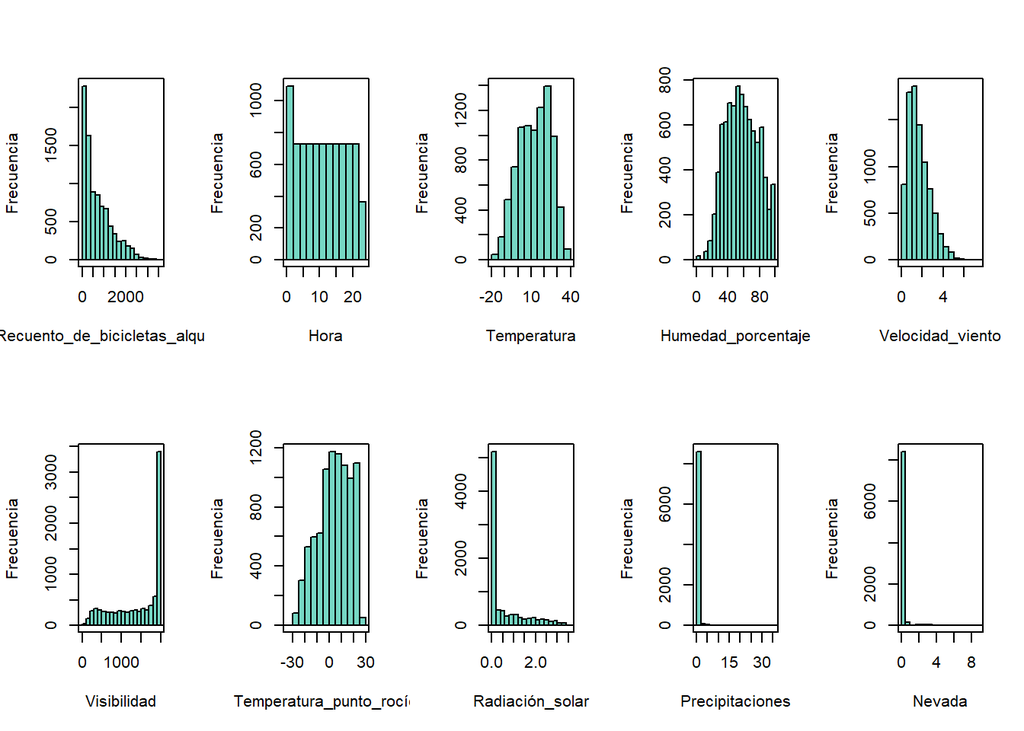

```r
#Visualización de la frecuencia de las variables
#Variables cuantitativas
par(mfrow=c(2,5))
#Recorro el juego de datos
for (i in 1:ncol(data)){
  #Verifico si la columna es de tipo numérica
  if (is.numeric(data[,i])){
    with(data, Hist(data[,i], scale="frequency", ylab="Frecuencia", xlab=colnames(data)[i], breaks="Sturges", col="#76D7C4"))
  }
}
```

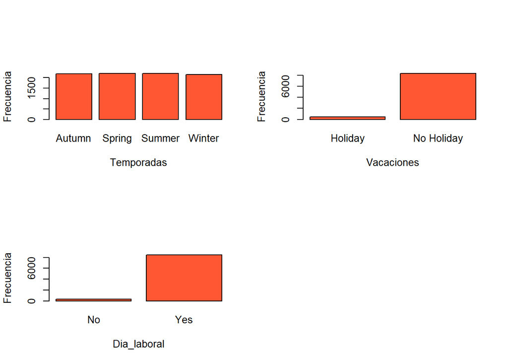

```r
#Variables cualitativas
par(mfrow=c(2,2))
#Recorro el juego de datos
for (i in 1:ncol(data)){
  #Verifico si la columna es de tipo caracter
  if (is.character(data[,i])){
    with(data, Barplot(data[,i], xlab=colnames(data)[i], ylab="Frecuencia", col="#FF5733"))
  }
}
```

#### 4.3.1 Anáilisis de los Histogramas y los Diagramas de Barras

**Atributos Cuantitativos Histogramas**

La máxima frecuencia de bicicletas alquiladas está dentro del rango de $[0,250]$.

Similar ocurre con la humedad a mayor humedad mayor frecuencia de bicicletas alquiladas, pero cuando se sobrepasa la humendad del $60%$ el alquiler de bicicletas empieza a disminuir lentamente.

Si la velocidad del viento aumenta, la frecuencia de bicicletas alquiladas disminuye.

Se alquilan mayor número de bicicletas cuando la visibilidad es mayor.

El mayor número de bicicletas alquiladas solo se da cuando las precipitaciones son bajas.

Se puede observar también que en gran porcentaje solo se alquilan bicicletas si no hay nevada o muy poca.

**Atributos Cualitativos Diagramas de barras**

Se observa mayor número de bicicletas alquiladas se dan cuando no hay días festivos.

#### 4.3.2 Hipótesis Iniciales

Con esta información puedo realizarme las primeras preguntas sobre el set de datos y realizar las primeras hipótesis que se contestarán en los siguientes apratados:

1. ¿El alquiler de bicicletas es mayor en la hora de ingreso y salida del horario laboral, es decir a las 07:00 y a las 17:00?
2. ¿Cuando se realizan mas alquileres de bicicletas entre semana o fines de semana?
3. ¿Que tempordas prefieren los usuarios alquilar bicicletas? ¿Prefieren los días soleados o los días de invierno?
4. ¿Los alquileres de bicicleta son mayores en días festivos o en días normales?
5. ¿En el transcurso de los años el alquiler de bicicleta aumenta o disminuye?
6. ¿Depende el número de alquiler de bicicletas de la radiación solar, es decir mientras mayor es la radiación solar menor es el número de usuarios o viceversa?

### 4.4 Outliers

Visualización de cajas de las variables cuantitativas

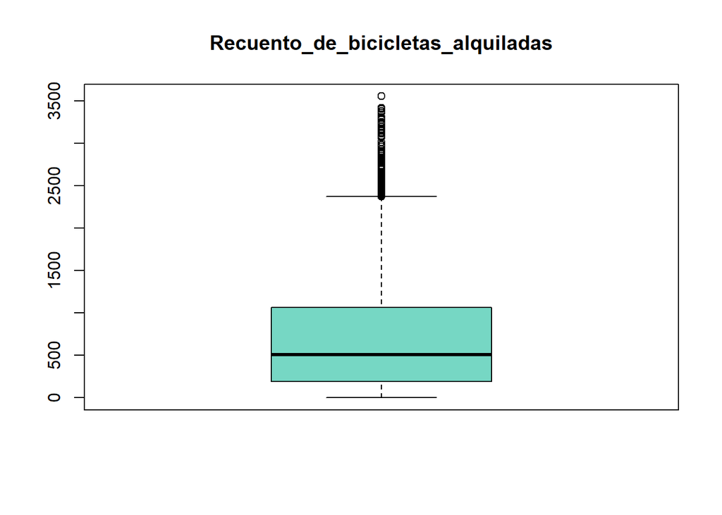

```
## [1] "Valores atípicos"
##   [1] 2401 2402 2401 2404 2692 2807 2574 2577 2558 2661 2392 3130 2405 2701 2379
##  [16] 2410 2906 2915 2479 2439 2403 3069 2450 3123 2454 2825 2916 3245 2656 3251
##  [31] 2650 3119 2534 3088 2505 2514 2460 3380 2788 2508 3227 2615 2404 3221 2649
##  [46] 3309 2797 2476 2431 2495 3404 2873 2579 2505 2474 2664 2479 2404 2962 2460
##  [61] 2891 2984 2441 2383 2451 2475 2497 2435 2474 2481 2429 2515 2430 3556 2809
##  [76] 2525 2378 2440 3384 2741 2519 3418 2811 2556 2436 3365 2732 2493 2387 3238
##  [91] 2779 2456 3172 2487 3113 2602 2965 2598 2398 3080 2637 2415 2594 3196 2557
## [106] 2931 3016 2884 2636 2770 2692 2640 2419 2405 2416 2481 2797 2628 2830 2528
## [121] 2836 3166 2491 3160 2468 2497 3154 3298 2518 3222 2455 2391 3256 2443 3146
## [136] 2826 3277 2489 3154 2422 2432 2397 2857 2400 2787 2514 2378 2618 2635 2716
## [151] 2445 2499 2631 2613 2415 2612 2632
## [1] "Cantidad de valores atípicos"
## [1] 157
```

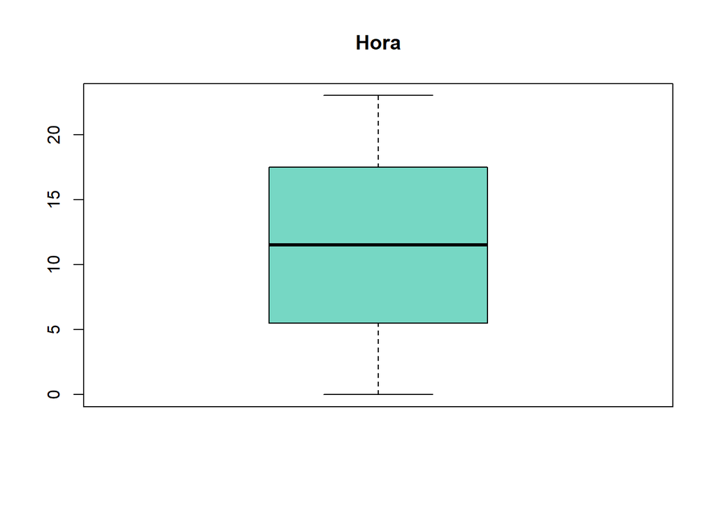

```
## [1] "Valores atípicos"
## integer(0)
## [1] "Cantidad de valores atípicos"
## [1] 0
```

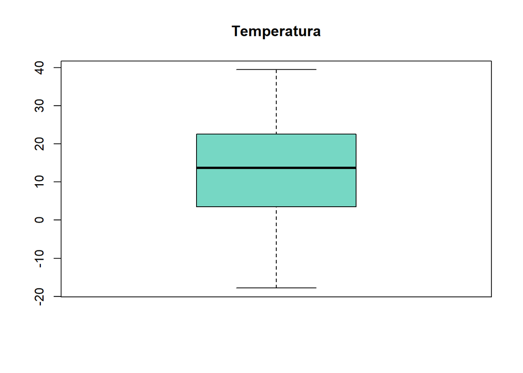

```
## [1] "Valores atípicos"
## numeric(0)
## [1] "Cantidad de valores atípicos"
## [1] 0
```

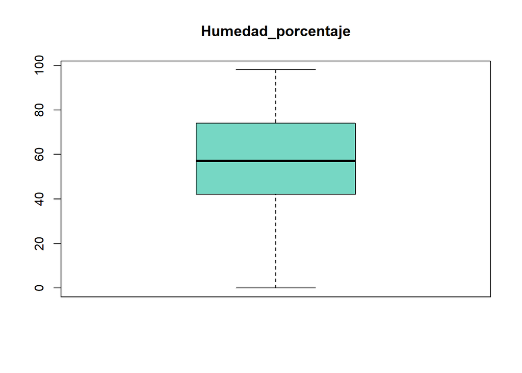

```
## [1] "Valores atípicos"
## integer(0)
## [1] "Cantidad de valores atípicos"
## [1] 0
```

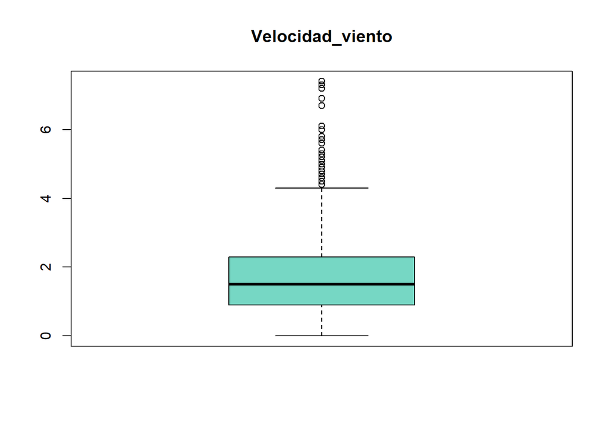

```
## [1] "Valores atípicos"
##   [1] 4.5 4.8 5.4 4.5 5.8 4.7 5.3 4.5 4.5 4.7 5.1 4.5 4.6 5.1 4.5 5.0 4.4 4.9
##  [19] 4.7 5.0 4.7 4.5 4.4 6.7 4.6 4.6 5.0 4.4 4.5 4.6 4.5 4.5 4.7 5.3 4.8 4.5
##  [37] 4.5 4.6 6.0 4.7 5.2 4.6 4.5 4.5 4.8 4.6 4.6 4.4 4.8 4.9 4.7 4.6 4.4 4.5
##  [55] 4.4 4.7 4.5 4.9 5.0 5.6 5.1 5.8 4.4 4.5 4.4 5.3 4.6 4.4 5.0 4.9 5.3 4.6
##  [73] 4.7 6.0 4.5 4.8 5.2 4.7 4.7 4.7 4.5 4.4 4.6 4.4 5.3 4.6 4.9 4.9 4.9 4.8
##  [91] 4.5 4.7 5.0 4.7 5.3 4.6 5.1 7.4 4.8 5.8 5.6 7.2 5.8 6.1 7.3 5.4 4.6 4.7
## [109] 4.4 4.6 5.1 4.9 4.8 4.4 4.7 4.7 4.8 4.8 4.6 4.9 5.1 4.6 4.7 4.5 4.8 5.3
## [127] 4.9 5.0 4.4 4.7 4.5 4.6 4.7 4.9 4.5 6.9 4.5 4.9 5.0 4.8 5.0 5.1 5.0 4.7
## [145] 4.4 4.6 4.4 4.5 4.7 5.0 5.0 4.9 5.0 5.4 4.9 4.6 4.4 5.7 4.9 4.7 5.3
## [1] "Cantidad de valores atípicos"
## [1] 161
```

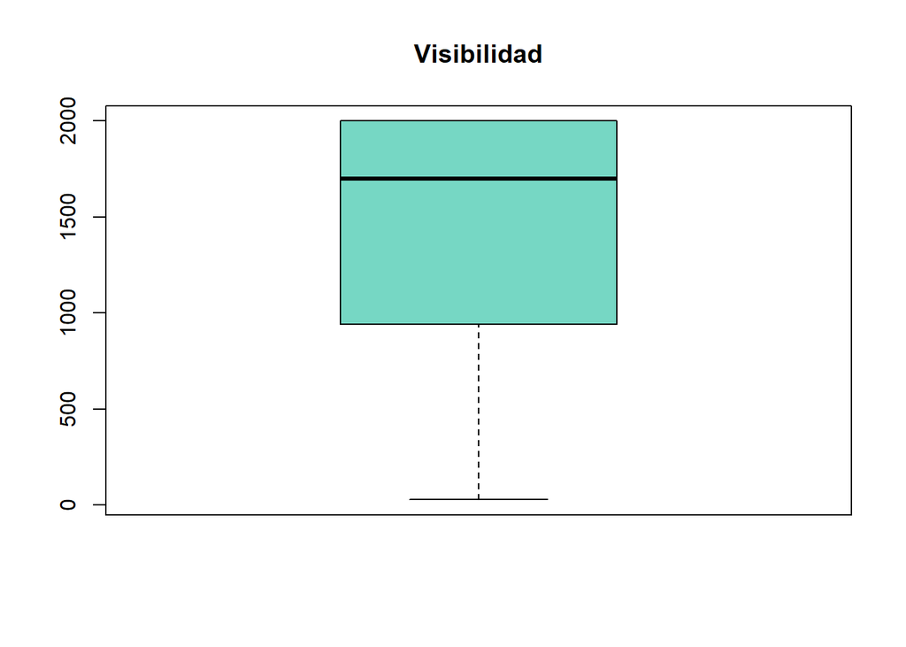

```
## [1] "Valores atípicos"
## integer(0)
## [1] "Cantidad de valores atípicos"
## [1] 0
```

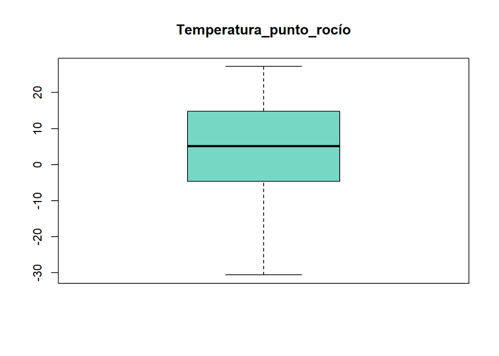

```
## [1] "Valores atípicos"
## numeric(0)
## [1] "Cantidad de valores atípicos"
## [1] 0
```

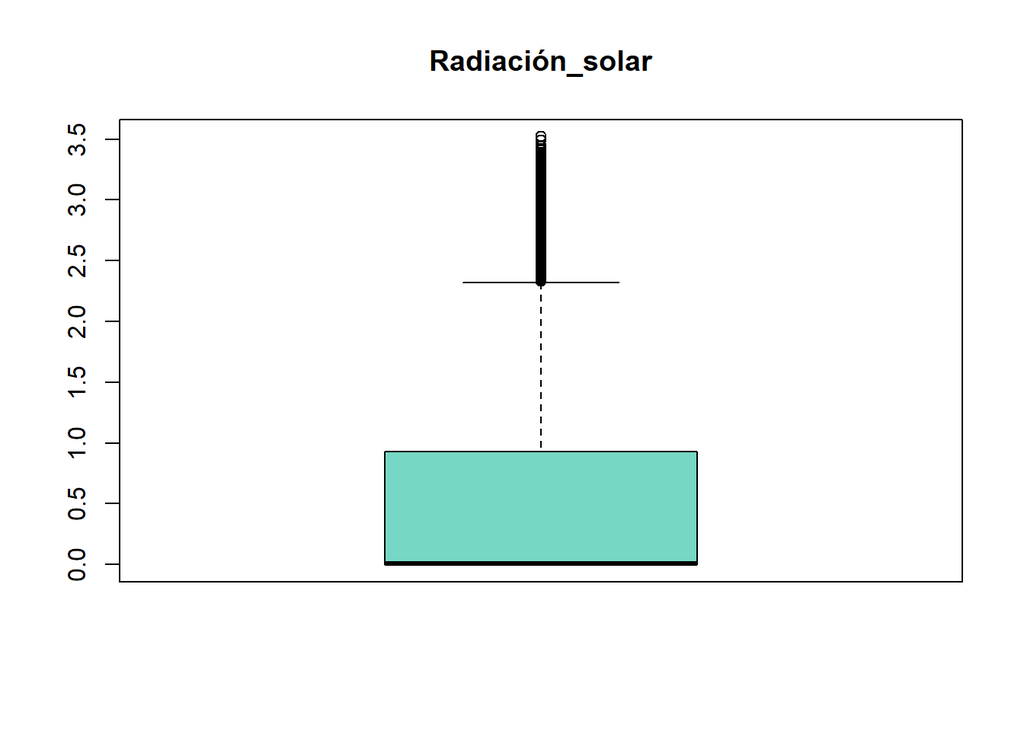

```
## [1] "Valores atípicos"
##   [1] 2.35 2.46 2.39 2.49 2.36 2.50 2.52 2.35 2.48 2.43 2.49 2.95 2.86 2.54 2.61
##  [16] 2.83 2.74 2.48 2.56 2.75 2.66 2.33 2.46 2.45 2.55 2.65 2.47 2.66 2.53 2.47
##  [31] 2.67 2.69 2.34 2.44 2.60 2.43 2.66 2.49 2.38 2.78 2.99 2.91 2.62 2.51 2.52
##  [46] 2.36 2.59 2.33 2.70 2.91 2.82 2.51 2.72 2.87 2.71 2.41 2.48 2.42 2.63 2.75
##  [61] 2.62 2.65 2.80 2.70 2.44 2.54 2.37 2.73 2.87 2.75 2.40 2.41 2.53 2.57 2.83
##  [76] 3.24 3.04 2.79 2.98 2.99 2.49 2.93 3.06 2.99 2.60 2.59 2.94 2.77 2.75 3.05
##  [91] 3.32 3.16 2.90 2.39 2.68 3.07 3.20 3.13 2.86 2.39 2.52 2.71 2.67 3.10 3.21
## [106] 3.11 2.80 2.66 3.03 3.16 3.01 2.80 2.82 3.13 3.27 3.17 2.88 2.52 2.79 2.89
## [121] 2.83 2.53 2.51 2.88 3.03 2.92 2.59 2.85 3.19 3.31 3.29 2.98 2.50 2.74 3.08
## [136] 3.18 3.12 2.75 2.55 2.67 2.84 2.66 2.51 2.89 2.99 2.91 2.66 2.84 3.18 3.25
## [151] 3.22 2.96 2.45 2.79 2.79 3.35 2.93 2.79 2.65 2.96 2.87 2.47 2.40 2.93 3.28
## [166] 3.39 3.31 3.00 2.49 2.56 2.74 2.51 2.57 2.72 2.33 3.05 2.35 2.46 2.89 3.15
## [181] 2.46 2.41 2.88 3.21 3.34 3.10 2.88 2.38 2.38 2.84 3.17 3.26 3.22 2.87 2.41
## [196] 2.53 3.08 3.17 2.52 2.40 2.38 2.74 2.67 2.70 2.88 3.14 2.51 2.61 3.12 3.42
```

[output cut: 31 more lines]

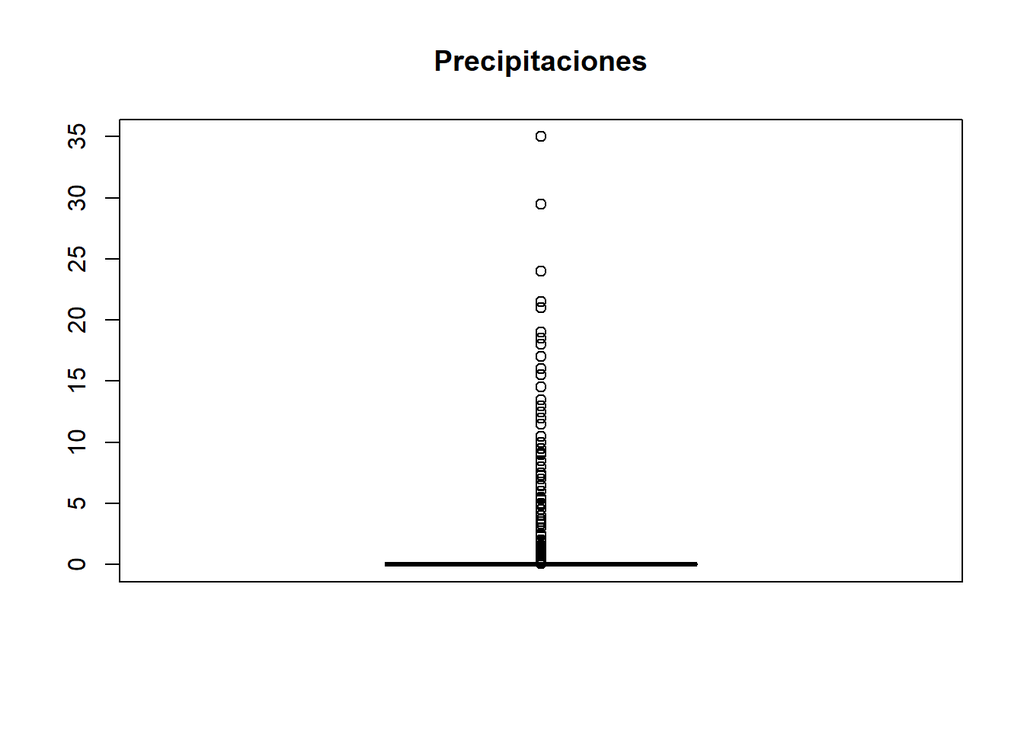

```
## [1] "Valores atípicos"
##   [1]  0.5  1.0  2.5  0.1  0.1  0.2  0.3  0.7  2.5  1.6  0.3  0.4  1.6  1.1  0.1
##  [16]  0.1  0.1  6.4  9.5  3.5  0.5  0.3  0.2  0.2  1.0  0.9  0.5  0.3  0.2  0.2
##  [31]  0.2  3.3  1.4  1.5  0.1  0.4  0.4  3.7  4.5  9.5  9.0  2.0  0.1  0.4  0.1
##  [46]  0.2  0.2  2.0  9.0  1.5  2.0  0.5  2.0  1.5  0.5  8.0 17.0  2.0  0.5  0.3
##  [61]  0.2  0.5  0.5  0.5  0.1  3.5  7.0  3.0  3.0  2.0  0.1  0.4  1.5  2.0  0.5
##  [76]  0.5  1.0  1.0  1.5  1.0  0.5  0.5  0.5  1.5  2.0  2.0  0.5  0.1  0.1  0.1
##  [91]  1.9  1.0  0.5  1.5  3.0  0.2  0.8  1.0  2.0  1.0  1.5  1.5  0.5  0.5  0.3
## [106]  0.2  1.0  0.5  0.5  1.5  2.5  4.0  3.0  2.0  0.1  0.9  0.5  3.5  2.5  7.0
## [121]  6.0  5.0  8.0  4.0  1.5  5.5  2.5  4.0  1.5  1.0  0.5  1.0  1.5  1.0  1.5
## [136]  0.1  2.4  0.5  0.4  0.1  1.0  3.5  4.0  0.5  0.5  1.0  1.0  0.1  0.4  0.5
## [151]  0.5  1.5  1.5  2.0  3.0  2.5  2.0  1.0  1.5  3.5  3.0  0.4  0.1  1.0  3.0
## [166]  2.5  3.5  2.0  3.0  2.0  3.0  1.5  1.5  2.0  2.0  1.0  0.5  1.5  1.0  0.5
## [181]  0.2  0.1  0.2  0.2  0.8  2.0  4.0  1.0 35.0  0.5  0.5  0.5  0.5  0.5  1.0
## [196]  2.5 19.0 13.5 10.0  2.0  2.5  1.5  0.5  2.5  1.5 12.5  4.0  6.0  2.5  1.0
```

[output cut: 24 more lines]

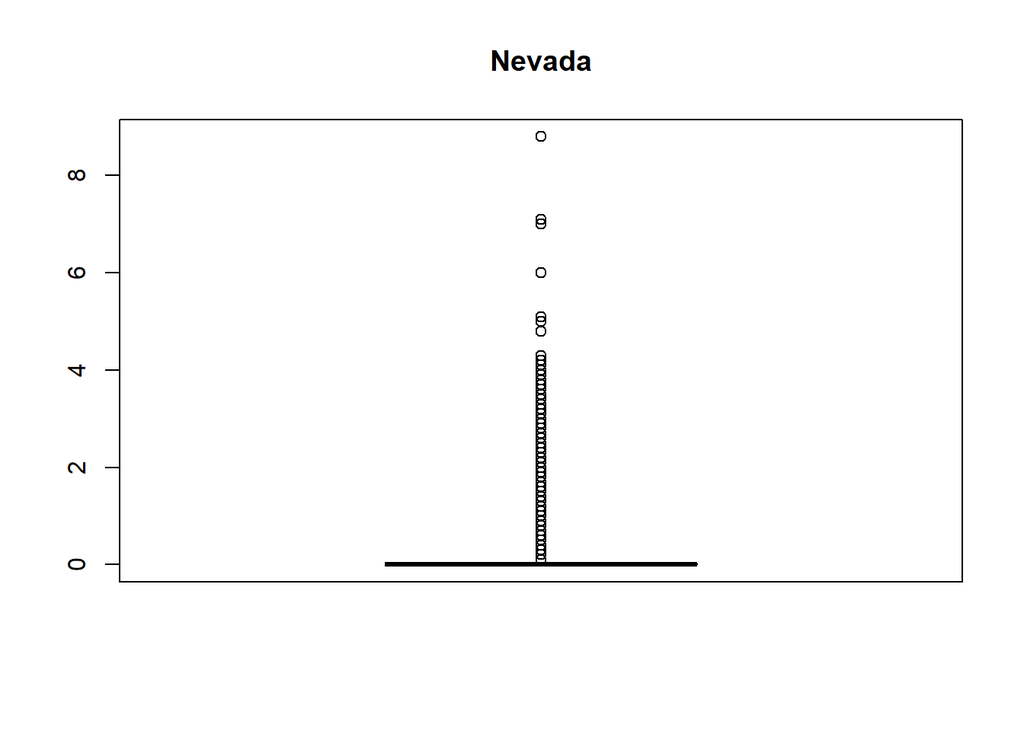

```
## [1] "Valores atípicos"
##   [1] 0.1 0.3 0.4 0.4 0.4 0.4 0.4 0.3 0.2 0.2 0.2 0.3 1.0 1.0 1.0 1.0 1.0 0.9
##  [19] 0.9 0.9 0.9 0.9 0.9 0.9 0.9 0.8 0.8 0.7 0.6 0.3 0.7 2.7 4.0 4.1 4.3 4.3
##  [37] 3.9 3.1 2.1 1.4 1.0 0.5 0.4 0.2 0.5 0.7 0.8 1.3 1.8 2.0 4.0 4.8 4.8 5.1
##  [55] 5.0 4.2 3.2 2.7 2.7 2.7 2.7 2.7 2.6 2.6 2.6 2.6 2.6 2.6 2.6 2.6 2.6 2.6
##  [73] 2.6 2.5 2.5 2.5 2.5 2.3 2.2 2.2 2.1 2.0 2.0 2.0 2.0 2.0 2.0 2.0 2.0 2.0
##  [91] 2.0 2.0 2.0 2.0 2.0 2.0 2.0 2.0 2.0 2.0 1.9 1.9 1.7 1.7 1.6 1.6 2.2 2.2
## [109] 2.2 2.4 2.4 2.3 2.2 2.2 2.2 2.2 2.2 2.2 2.2 2.2 2.2 2.2 2.2 2.1 2.0 1.9
## [127] 1.8 1.6 1.0 0.9 0.8 0.8 0.8 0.8 0.8 0.8 0.8 0.8 0.8 0.8 0.7 0.7 0.7 0.7
## [145] 0.7 0.7 0.6 0.5 0.2 0.6 1.2 1.2 1.2 1.2 1.2 1.2 1.2 1.2 1.1 1.1 1.0 0.7
## [163] 0.5 1.0 1.0 1.0 1.0 1.0 1.0 1.0 0.9 0.9 0.9 0.9 0.8 0.7 0.6 0.5 0.5 0.4
## [181] 0.3 0.2 0.2 0.5 0.8 0.8 0.8 0.8 0.8 0.8 0.7 0.7 0.7 0.6 0.5 0.5 0.4 0.3
## [199] 0.3 0.2 0.2 0.4 0.6 0.6 0.4 0.2 1.0 1.0 1.0 1.0 1.0 1.0 1.0 1.0 1.0 1.0
## [217] 1.0 1.0 1.0 1.0 1.0 1.0 1.0 1.0 1.0 1.0 1.0 1.0 1.0 0.9 0.9 0.9 0.9 0.9
## [235] 0.9 0.9 0.9 0.9 0.9 0.9 0.9 0.9 0.9 0.9 0.9 0.9 0.9 0.9 0.9 0.9 0.8 0.7
## [253] 0.7 0.7 0.7 0.7 0.7 0.7 0.7 0.7 0.7 0.7 0.7 0.7 0.7 0.7 0.7 0.7 0.6 0.6
## [271] 0.6 0.6 0.6 0.6 0.5 0.5 0.5 0.5 0.5 0.5 0.5 0.5 0.5 0.5 0.5 0.5 0.5 0.5
## [289] 0.5 0.5 0.5 0.5 0.5 0.5 0.5 0.5 0.5 0.5 0.4 0.4 0.4 0.3 0.3 0.3 0.3 0.3
## [307] 0.3 0.3 0.3 0.3 0.3 0.3 0.3 0.3 0.3 0.3 0.3 0.3 0.3 0.3 0.3 0.3 0.2 0.6
## [325] 2.0 3.0 3.3 3.5 3.5 3.5 3.5 3.5 3.5 3.5 3.5 3.5 3.5 3.5 3.5 3.4 3.2 3.0
## [343] 3.0 2.8 2.5 2.2 1.8 1.8 1.6 1.6 1.6 1.6 1.6 1.6 1.6 1.6 1.6 1.6 1.6 1.6
## [361] 1.6 1.6 1.6 1.6 1.5 1.4 1.3 1.0 0.5 0.1 0.2 0.3 0.3 0.3 0.3 0.3 0.2 0.2
## [379] 0.4 4.0 4.1 4.1 3.9 3.8 3.8 3.8 3.7 3.7 3.7 3.4 1.7 0.6 1.3 4.0 7.1 8.8
## [397] 8.8 7.0 6.0 5.0 4.1 3.6 3.5 3.5 3.3 3.3 3.2 3.2 3.0 3.0 2.9 2.9 2.8 2.6
## [415] 2.5 2.5 2.5 2.5 2.5 2.4 2.3 2.2 1.8 1.3 1.1 0.8 0.4 0.4 0.4 0.4 0.4 0.4
## [433] 0.4 0.3 0.3 0.3 0.3 0.3 0.3 0.3 0.3 0.3 0.2
## [1] "Cantidad de valores atípicos"
## [1] 443
```

```r
# Genero un bucle para graficar las cajas por cada una de las columnas cuantitativas del juego de datos solicitada
for (i in 1:(ncol(data))){
  if (is.numeric(data[,i])){
    boxplot(data[,i], main = colnames(data)[i],col=(c("#76D7C4")))
    #Valores atipicos
    print('Valores atípicos')
    elementos <- boxplot.stats(data[,i])$out #muestra los valores atípicos
    print(elementos)
    longitud <- length(elementos) #Cantidad de valores atípicos
    print('Cantidad de valores atípicos')
    print(longitud)
  }
}
```

```r
print(paste('El porcentaje de outliers es',1930/8760*100,'%'))
```

```
## [1] "El porcentaje de outliers es 22.0319634703196 %"
```

El porcentaje de outliers representa el $22%$ del total de datos, un porcentaje medio alto dependiendo del análisis futuro decidiré si considerar estos outliers o no, por el momento se mantendrán.

## 5. Comprobación de la normalidad

```
## [1] "Recuento_de_bicicletas_alquiladas"
##
##  D'Agostino skewness test
##
## data:  data[, i]
## skew = 1.1532, z = 35.7712, p-value < 2.2e-16
## alternative hypothesis: data have a skewness
```

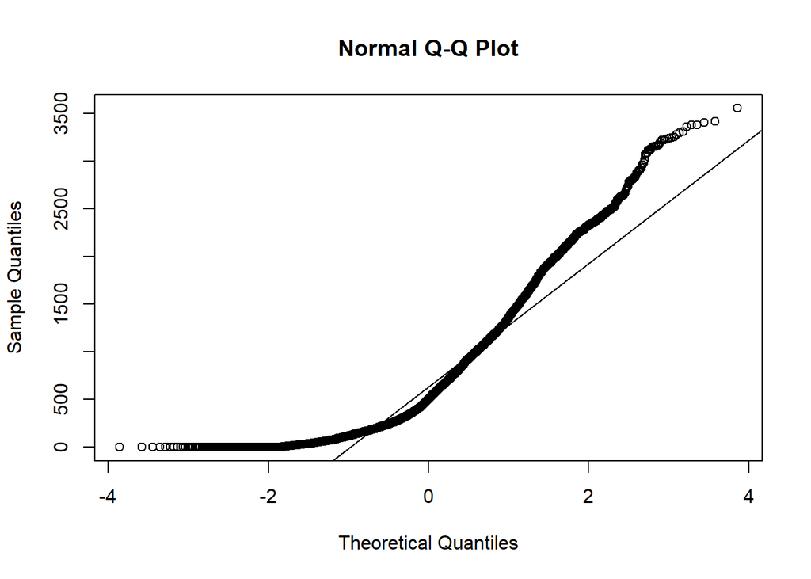

```
## [1] "Hora"
##
##  D'Agostino skewness test
##
## data:  data[, i]
## skew = 0, z = 0, p-value = 1
## alternative hypothesis: data have a skewness
```

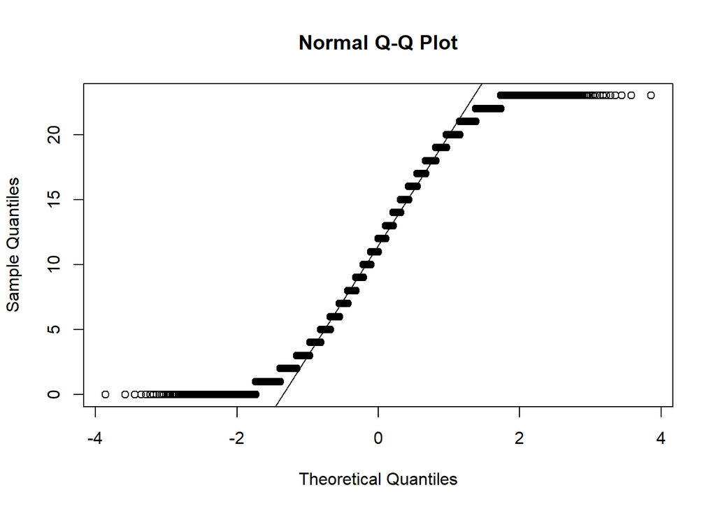

```
## [1] "Temperatura"
##
##  D'Agostino skewness test
##
## data:  data[, i]
## skew = -0.19829, z = -7.51074, p-value = 5.884e-14
## alternative hypothesis: data have a skewness
```

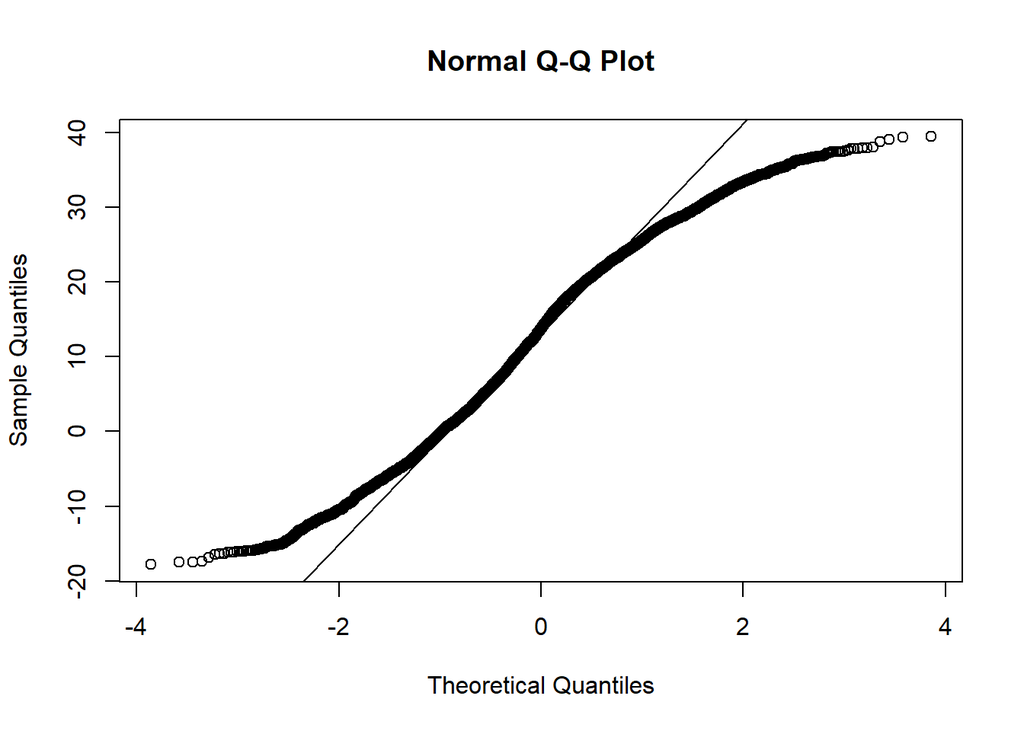

```
## [1] "Humedad_porcentaje"
##
##  D'Agostino skewness test
##
## data:  data[, i]
## skew = 0.059569, z = 2.276053, p-value = 0.02284
## alternative hypothesis: data have a skewness
```

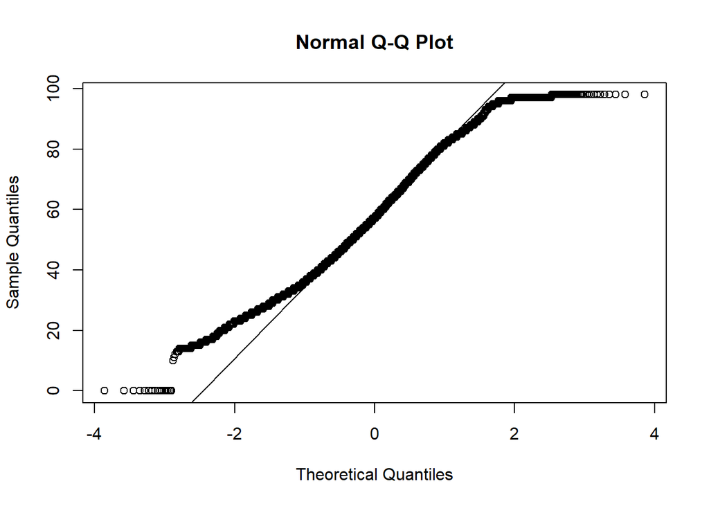

```
## [1] "Velocidad_viento"
##
##  D'Agostino skewness test
##
## data:  data[, i]
## skew = 0.8908, z = 29.4935, p-value < 2.2e-16
## alternative hypothesis: data have a skewness
```

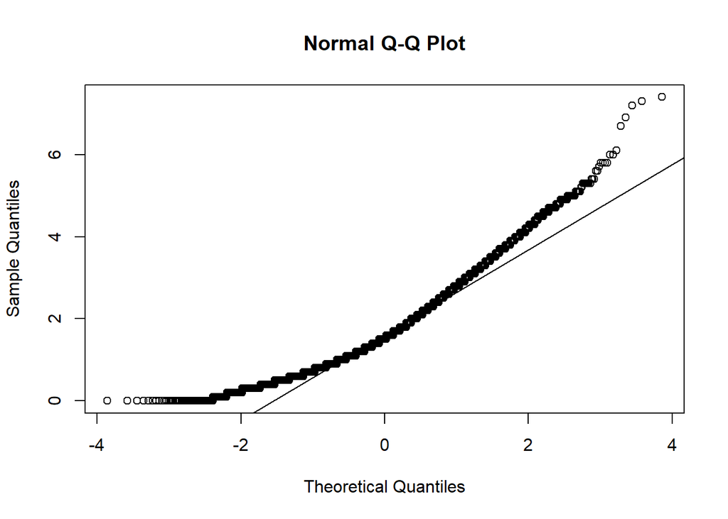

```
## [1] "Visibilidad"
##
##  D'Agostino skewness test
##
## data:  data[, i]
## skew = -0.70167, z = -24.30914, p-value < 2.2e-16
## alternative hypothesis: data have a skewness
```

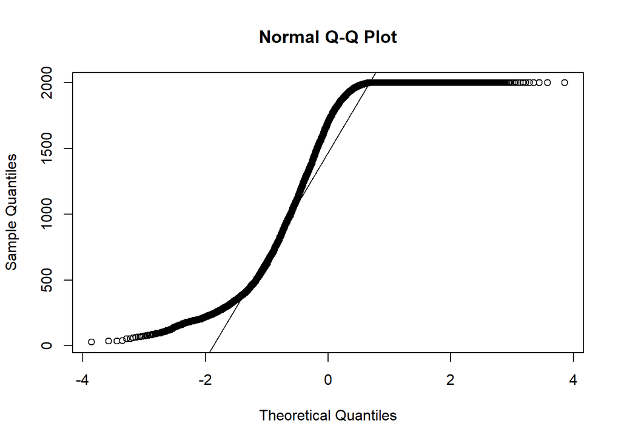

```
## [1] "Temperatura_punto_rocío"
##
##  D'Agostino skewness test
##
## data:  data[, i]
## skew = -0.36724, z = -13.61010, p-value < 2.2e-16
## alternative hypothesis: data have a skewness
```

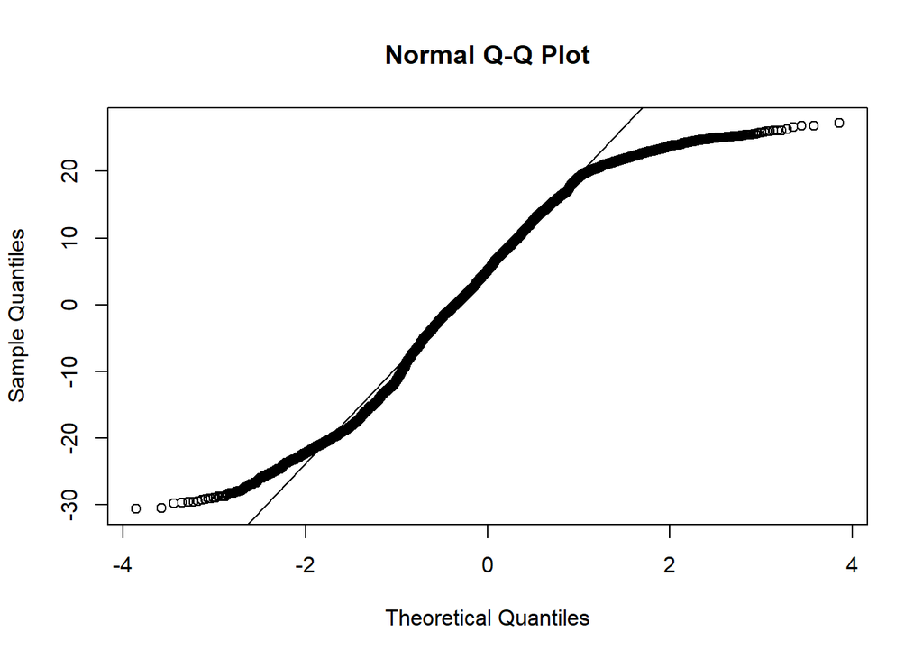

```
## [1] "Radiación_solar"
##
##  D'Agostino skewness test
##
## data:  data[, i]
## skew = 1.5038, z = 42.8147, p-value < 2.2e-16
## alternative hypothesis: data have a skewness
```

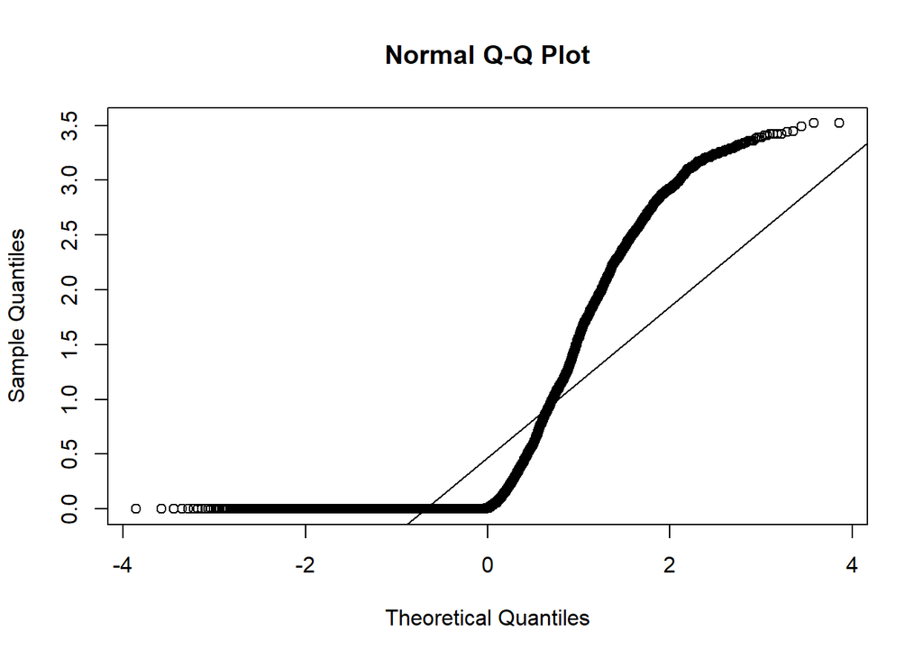

```
## [1] "Precipitaciones"
##
##  D'Agostino skewness test
##
## data:  data[, i]
## skew = 14.531, z = 111.668, p-value < 2.2e-16
## alternative hypothesis: data have a skewness
```

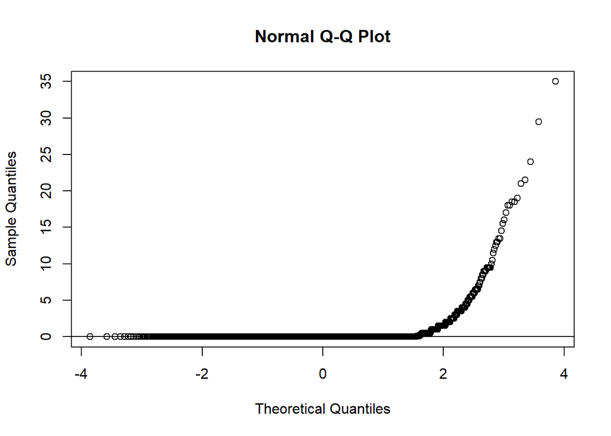

```
## [1] "Nevada"
##
##  D'Agostino skewness test
##
## data:  data[, i]
## skew = 8.4394, z = 94.7281, p-value < 2.2e-16
## alternative hypothesis: data have a skewness
```

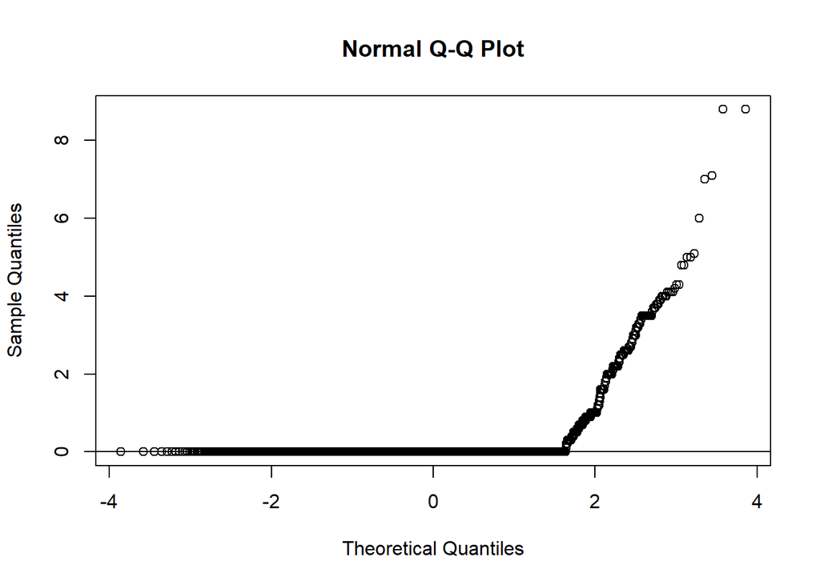

```r
#Verifico normalidad
for (i in 1:(ncol(data))){
  if (is.numeric(data[,i])){
    print(colnames(data)[i])
    skewness(data[,i]) #Para tratar de ser un poco más exacto voy a utilizar un método numérico para el test de normalidad.
    print(agostino.test(data[,i])) #D'Agostino skewness test
    qqnorm(data[,i])
    qqline(data[,i])
  }
}
```

Segundo método para verificar Normalidad

```r
alpha = 0.05
col.names = colnames(data)
for (i in 1:ncol(data)) {
  if (i == 1) cat("Variables que no siguen una distribución normal:\n")
  if (is.integer(data[,i]) | is.numeric(data[,i])) {
    p_val = ad.test(data[,i])$p.value
    if (p_val < alpha) {
      cat(col.names[i])
      # Format output
      if (i < ncol(data) - 1) cat(", ")
      if (i %% 3 == 0) cat("\n")
    }
  }
}
```

```
## Variables que no siguen una distribución normal:
## Recuento_de_bicicletas_alquiladas, Hora,
## Temperatura, Humedad_porcentaje, Velocidad_viento,
## Visibilidad, Temperatura_punto_rocío, Radiación_solar,
## Precipitaciones, Nevada,
```

### 5.1 Análisis de normalidad

Para tratar de ser un poco más exacto voy a utilizar un método numérico para el test de normalidad.

El punto de corte que se suele utilizar es $P = 0.05$:

## 6. Comprobación de la homogeneidad de la varianza

```r
fligner.test(Recuento_de_bicicletas_alquiladas ~ Hora, data = data)
```

```
##
##  Fligner-Killeen test of homogeneity of variances
##
## data:  Recuento_de_bicicletas_alquiladas by Hora
## Fligner-Killeen:med chi-squared = 3517.7, df = 23, p-value < 2.2e-16
```

```r
fligner.test(Recuento_de_bicicletas_alquiladas ~ Temperatura, data = data)
```

```
##
##  Fligner-Killeen test of homogeneity of variances
##
## data:  Recuento_de_bicicletas_alquiladas by Temperatura
## Fligner-Killeen:med chi-squared = 2622.8, df = 545, p-value < 2.2e-16
```

```r
fligner.test(Recuento_de_bicicletas_alquiladas ~ Humedad_porcentaje, data = data)
```

```
##
##  Fligner-Killeen test of homogeneity of variances
##
## data:  Recuento_de_bicicletas_alquiladas by Humedad_porcentaje
## Fligner-Killeen:med chi-squared = 853.15, df = 89, p-value < 2.2e-16
```

```r
fligner.test(Recuento_de_bicicletas_alquiladas ~ Velocidad_viento, data = data)
```

```
##
##  Fligner-Killeen test of homogeneity of variances
##
## data:  Recuento_de_bicicletas_alquiladas by Velocidad_viento
## Fligner-Killeen:med chi-squared = 582.17, df = 64, p-value < 2.2e-16
```

```r
fligner.test(Recuento_de_bicicletas_alquiladas ~ Visibilidad, data = data)
```

```
##
##  Fligner-Killeen test of homogeneity of variances
##
## data:  Recuento_de_bicicletas_alquiladas by Visibilidad
## Fligner-Killeen:med chi-squared = 2344.9, df = 1788, p-value < 2.2e-16
```

```r
fligner.test(Recuento_de_bicicletas_alquiladas ~ Temperatura_punto_rocío, data = data)
```

```
##
##  Fligner-Killeen test of homogeneity of variances
##
## data:  Recuento_de_bicicletas_alquiladas by Temperatura_punto_rocío
## Fligner-Killeen:med chi-squared = 1994.3, df = 555, p-value < 2.2e-16
```

```r
fligner.test(Recuento_de_bicicletas_alquiladas ~ Radiación_solar, data = data)
```

```
##
##  Fligner-Killeen test of homogeneity of variances
##
## data:  Recuento_de_bicicletas_alquiladas by Radiación_solar
## Fligner-Killeen:med chi-squared = 897.2, df = 344, p-value < 2.2e-16
```

```r
fligner.test(Recuento_de_bicicletas_alquiladas ~ Precipitaciones, data = data)
```

```
##
##  Fligner-Killeen test of homogeneity of variances
##
## data:  Recuento_de_bicicletas_alquiladas by Precipitaciones
## Fligner-Killeen:med chi-squared = 567.62, df = 60, p-value < 2.2e-16
```

```r
fligner.test(Recuento_de_bicicletas_alquiladas ~ Nevada, data = data)
```

```
##
##  Fligner-Killeen test of homogeneity of variances
##
## data:  Recuento_de_bicicletas_alquiladas by Nevada
## Fligner-Killeen:med chi-squared = 541.44, df = 50, p-value < 2.2e-16
```

En ninguno de los casos de comprueba Homogeneidad de la varianza.

**Pero podemos concluir revisando los gráficos también:**

Por otro lado el Q_Q plot, muestra que los datos no se ajustan exactamente a una distribución normal para los valores inferiores o superiores de la gráfica, pero sí para los valores centrales. Por tanto, existen algunos valores extremos que pueden afectar a la condición de normalidad.

## 7. Pruebas Estadisticas

### 7.1 Correlaciones

Realizo el cálculo y la visualización para comprender la correlación de los atributos en caso de que exista alguna correlación entre ellos.

```r
corr_matrix <- matrix(nc = 2, nr = 0)
colnames(corr_matrix) <- c("estimate", "p-value")
data_num <- data.frame(data['Recuento_de_bicicletas_alquiladas'], data['Hora'],data['Temperatura'], data['Humedad_porcentaje'], data['Velocidad_viento'], data['Visibilidad'], data['Temperatura_punto_rocío'], data['Radiación_solar'], data['Precipitaciones'], data['Nevada']) #Construyo un dataset con los atributos numéricos
```

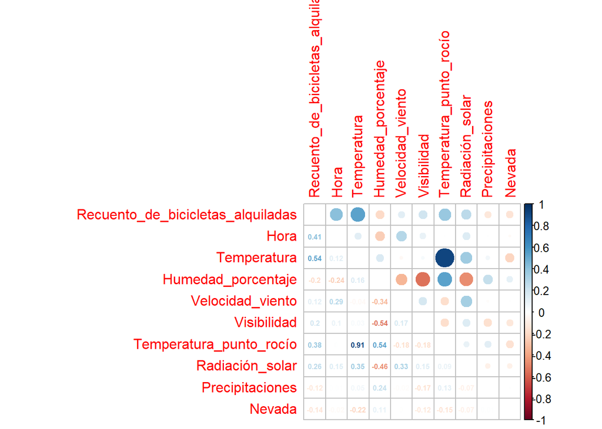

```r
corr_matrix <- matrix(nc = 2, nr = 0)
colnames(corr_matrix) <- c("estimate", "p-value")
# Calcular el coeficiente de correlación para cada variable cuantitativa
for (i in 1:(ncol(data_num) - 1)) {
  if (is.integer(data_num[,i]) | is.numeric(data_num[,i])) {
    spearman_test = cor.test(data_num[,i],
    data_num[,length(data_num)],
    method = "spearman")
    corr_coef = spearman_test$estimate
    p_val = spearman_test$p.value
    # Add row to matrix
    pair = matrix(ncol = 2, nrow = 1)
    pair[1][1] = corr_coef
    pair[2][1] = p_val
    corr_matrix <- rbind(corr_matrix, pair)
    rownames(corr_matrix)[nrow(corr_matrix)] <- colnames(data_num)[i]
  }
}

MC <- cor(data_num) #permite ejecutar una matriz de correlación
corrplot.mixed(MC, tl.pos = "lt", number.cex = 0.5) #Visualizo la correlación de los atributos
```

```r
print(corr_matrix) #Imprimo los datos de correlación
```

```
##                                       estimate       p-value
## Recuento_de_bicicletas_alquiladas -0.220760280  3.698167e-97
## Hora                              -0.031921068  2.808249e-03
## Temperatura                       -0.307068545 1.248150e-190
## Humedad_porcentaje                 0.050255090  2.527225e-06
## Velocidad_viento                   0.029232240  6.215663e-03
## Visibilidad                       -0.074217543  3.526043e-12
## Temperatura_punto_rocío           -0.249373747 2.689327e-124
## Radiación_solar                   -0.076845148  5.936353e-13
## Precipitaciones                    0.001896111  8.591620e-01
```

```r
prop.table(table(data$Temporadas)) #Reviso los Valores dentro de las estaciones en la temporada
```

```
##
##    Autumn    Spring    Summer    Winter
## 0.2493151 0.2520548 0.2520548 0.2465753
```

```r
#Convierto las variables discretas en factores (Temporada, Vacaciones, Dia_laboral, Hora)
data$Temporadas=as.factor(data$Temporadas)
data$Vacaciones=as.factor(data$Vacaciones)
data$Dia_funcional=as.factor(data$Dia_laboral)
data$Hora=as.factor(data$Hora)
```

## 8. Prueba de hipótesis (Análisis Multivariante)

**Tendecia Horaria:**

Veo la tendencia horaria del recuento durante horas y verifico si la hipótesis es correcta o no.

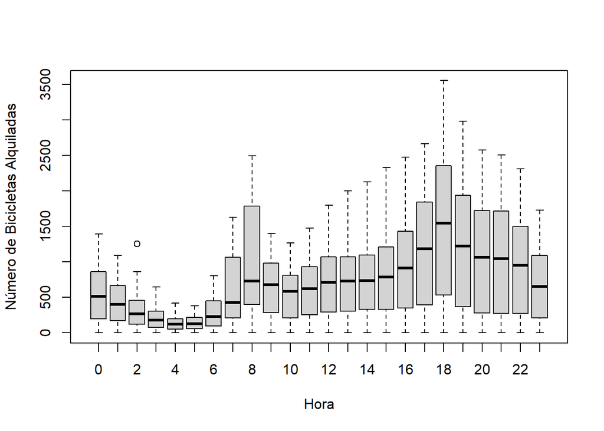

```r
#Demanda de uso compartido de bicicletas, pronosticar la demanda de alquiler de bicicletas
boxplot(data$Recuento_de_bicicletas_alquiladas~data$Hora,xlab="Hora", ylab="Número de Bicicletas Alquiladas") # Visualizo con un bloxplot
```

Tendencia de la demanda de bicicletas en horas del día

Se pueden observar Rangos en los que hay mayor demanda de bicicletas:

[output not shown]

**Tendecia Diaria:**

El gráfico muestra la demanda de alquiler de bicicletas durante días de las semana.

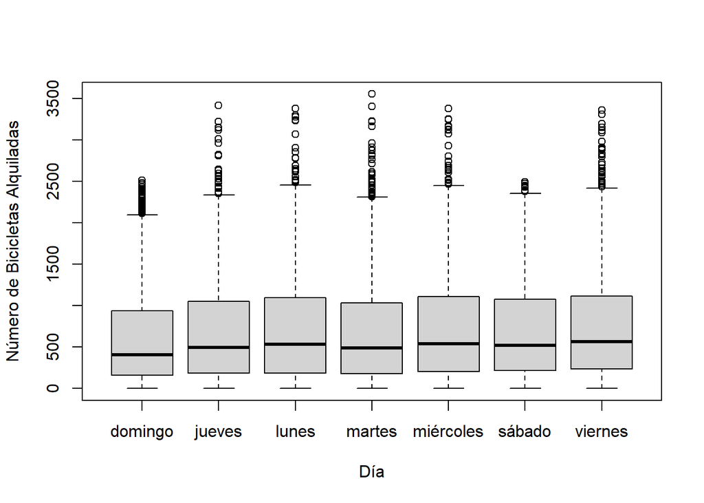

```r
#Paso las fechas a nombres de días
dias<-weekdays(data$Fecha)
data$dias=dias #Agrego la columna días al Dataframe data
boxplot(data$Recuento_de_bicicletas_alquiladas~data$dias,xlab="Día", ylab="Número de Bicicletas Alquiladas") # Visualizo con un bloxplot
```

Tendencia de la demanda de bicicletas en los días de la semana, practicamente no varía

**Tendecia Temporada:**

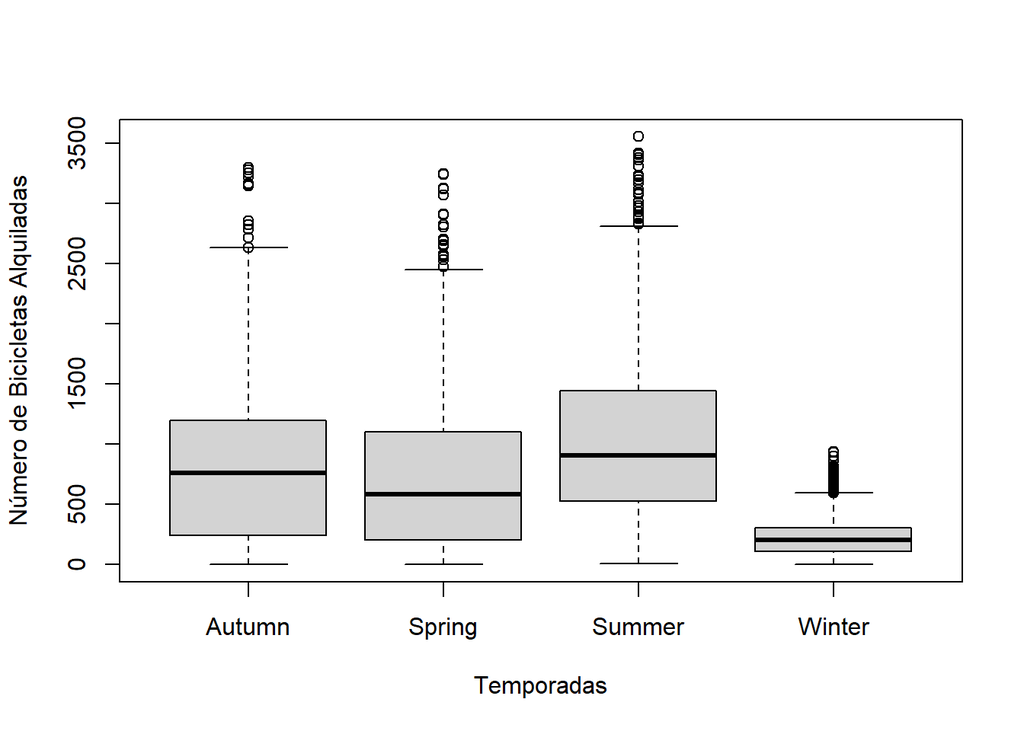

```r
boxplot(data$Recuento_de_bicicletas_alquiladas~data$Temporadas,xlab="Temporadas", ylab="Número de Bicicletas Alquiladas") # Visualizo con un bloxplot
```

Tendencia de la demanda de bicicletas en temporadas, en verano se tiene mayor demanda de Bicicletas

**Tendecia Días Festivos:**

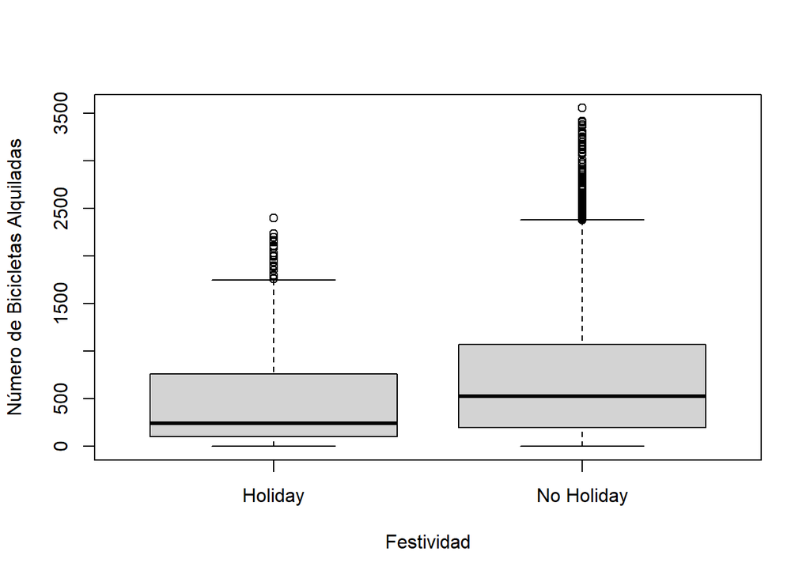

```r
boxplot(data$Recuento_de_bicicletas_alquiladas~data$Vacaciones,xlab="Festividad", ylab="Número de Bicicletas Alquiladas") # Visualizo con un bloxplot
```

Tendencia de la demanda de bicicletas en días festivos, en días no festivos la tendencia de alquiler de bicicletas es mayor

**Tendecia Años:**

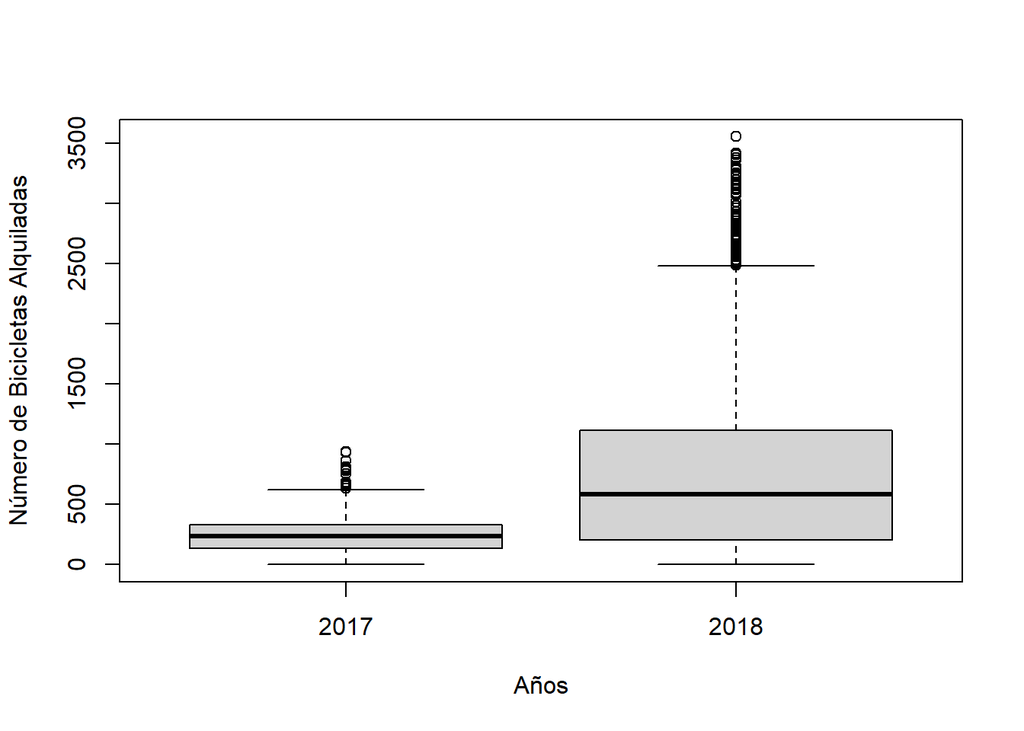

```r
data$anio <- format(data$Fecha, "%Y") #Capturo solo el año del formato fecha
data$anio=as.factor(data$anio) #Agrego al dataframe un nuevo atributo año como factor
boxplot(data$Recuento_de_bicicletas_alquiladas~data$anio,xlab="Años", ylab="Número de Bicicletas Alquiladas") # Visualizo con un bloxplot
```

Tendencia de la demanda de bicicletas por años, en el 2018 aumenta la demanda de alquiler de bicicletas